# Tipología y ciclo de vida de los datos

PRÁCTICA 2: Limpieza y análisis de datos

Autores: Eleazar Morales Díaz y Susana Vila Melero

5/6/2021

## 1. Descripción del dataset.

¿Qué grupo tiene mayor probabilidad de sobrevivir? ¿Hay relación entre categoría del billete y el pais o puerto de embarque?

Hemos elegido como dataset para realizar nuestra práctica el dataset de “Titanic”, ya que nos permite realizar tareas predictivas sobre la variable **Survived**. En esa línea nuestro objetivo será analizar qué subconjunto de personas tendría mayor probabilidad de sobrevivir en el Titanic, a partir de los datos contenidos en el conjunto de datos. Estudiaremos también qué relación hay entre la categoría del billete y el país/puerto de embarque.

El dataset consta de 2.207 registros y 11 variables que se describen a continuación:

- **name**: nombre del pasajero (string).
- **gender**: información respecto al género del pasajero (factor con dos niveles).
- **age**: la edad del pasajero el día del naufragio. La edad de los bebés( menores de 12 meses) se proporciona como una fracción de un año (valor numérico).
- **class**: la clase para los pasajeros o el tipo de servicio para los miembros de la tripulación (factor).
- **embarked**: lugar de embarque del pasajero (factor).
- **country**: lugar de procedencia del pasajero (factor).
- **ticketno**: número de pasaje de los pasajeros, NA en el caso de ser miembros de la tripulación (valor numérico).
- **fare**: Precio del pasaje, NA para miembros de la tripulación, músicos y empleados de la compañía naviera (valor numérico).
- **sibsp**: número de esposas/hermanos a bordo, tomado del dataset Vanderbild (factor ordenado).
- **parch**: número de padres/hijos a bordo, tomado del dataset Vanderbild (factor ordenado).
- **survived**: información respecto a si el pasajero sobrevivió o no al naufragio (factor con dos niveles).

## 2. Integración y selección de los datos de interés a analizar.

El primer paso será cargar las librerias y el dataset con el que vamos a trabajar.Una vez cargado, analizaremos su estructura y el tipo de variable y lo adecuaremos a nuestro estudio.

```r
# Cargamos las librerías
library(ggplot2)
library(dplyr)
library(RColorBrewer)
library(scales)
library(stats)
theme_set(theme_bw())

# Cargamos el dataset
ds <- read.csv("./data/titanic.csv", header=TRUE, fileEncoding="UTF-8")

#Hacemos una primera inspección
str(ds)
```

```
## 'data.frame':    2207 obs. of  11 variables:
##  $ name    : chr  "Abbing, Mr. Anthony" "Abbott, Mr. Eugene Joseph" "Abbott, Mr. Rossmore Edward" "Abbott, Mrs. Rhoda Mary 'Rosa'" ...
##  $ gender  : chr  "male" "male" "male" "female" ...
##  $ age     : num  42 13 16 39 16 25 30 28 27 20 ...
##  $ class   : chr  "3rd" "3rd" "3rd" "3rd" ...
##  $ embarked: chr  "S" "S" "S" "S" ...
##  $ country : chr  "United States" "United States" "United States" "England" ...
##  $ ticketno: int  5547 2673 2673 2673 348125 348122 3381 3381 2699 3101284 ...
##  $ fare    : num  7.11 20.05 20.05 20.05 7.13 ...
##  $ sibsp   : int  0 0 1 1 0 0 1 1 0 0 ...
##  $ parch   : int  0 2 1 1 0 0 0 0 0 0 ...
##  $ survived: chr  "no" "no" "no" "yes" ...
```

```r
summary(ds)
```

```
##      name              gender               age             class
##  Length:2207        Length:2207        Min.   : 0.1667   Length:2207
##  Class :character   Class :character   1st Qu.:22.0000   Class :character
##  Mode  :character   Mode  :character   Median :29.0000   Mode  :character
##                                        Mean   :30.4367
##                                        3rd Qu.:38.0000
##                                        Max.   :74.0000
##                                        NA's   :2
##    embarked           country             ticketno            fare
##  Length:2207        Length:2207        Min.   :      2   Min.   :  3.030
##  Class :character   Class :character   1st Qu.:  14262   1st Qu.:  7.181
##  Mode  :character   Mode  :character   Median : 111426   Median : 14.090
##                                        Mean   : 284216   Mean   : 33.405
##                                        3rd Qu.: 347077   3rd Qu.: 31.061
##                                        Max.   :3101317   Max.   :512.061
##                                        NA's   :891       NA's   :916
##      sibsp            parch          survived
##  Min.   :0.0000   Min.   :0.0000   Length:2207
##  1st Qu.:0.0000   1st Qu.:0.0000   Class :character
##  Median :0.0000   Median :0.0000   Mode  :character
##  Mean   :0.4996   Mean   :0.3856
##  3rd Qu.:1.0000   3rd Qu.:0.0000
##  Max.   :8.0000   Max.   :9.0000
##  NA's   :900      NA's   :900
```

```r
#Convertimos las variables carácter a variables factor
ds$gender = as.factor(ds$gender)
ds$class = as.factor(ds$class)
ds$embarked = as.factor(ds$embarked)
ds$survived = as.factor(ds$survived)
str(ds)
```

```
## 'data.frame':    2207 obs. of  11 variables:
##  $ name    : chr  "Abbing, Mr. Anthony" "Abbott, Mr. Eugene Joseph" "Abbott, Mr. Rossmore Edward" "Abbott, Mrs. Rhoda Mary 'Rosa'" ...
##  $ gender  : Factor w/ 2 levels "female","male": 2 2 2 1 1 2 2 1 2 2 ...
##  $ age     : num  42 13 16 39 16 25 30 28 27 20 ...
##  $ class   : Factor w/ 7 levels "1st","2nd","3rd",..: 3 3 3 3 3 3 2 2 3 3 ...
##  $ embarked: Factor w/ 4 levels "B","C","Q","S": 4 4 4 4 4 4 2 2 2 4 ...
##  $ country : chr  "United States" "United States" "United States" "England" ...
##  $ ticketno: int  5547 2673 2673 2673 348125 348122 3381 3381 2699 3101284 ...
##  $ fare    : num  7.11 20.05 20.05 20.05 7.13 ...
##  $ sibsp   : int  0 0 1 1 0 0 1 1 0 0 ...
##  $ parch   : int  0 2 1 1 0 0 0 0 0 0 ...
##  $ survived: Factor w/ 2 levels "no","yes": 1 1 1 2 2 2 1 2 2 2 ...
```

Ya tenemos el dataset cargado y con las variables transformadas para poder trabajar con él.

## 3. Limpieza de datos

### 3.1. Identificación y tratamiento de ceros o elementos vacíos.

Vamos a contar el total de **NAs** de nuestro dataset.

```r
sum(is.na(ds))
```

```
## [1] 3690
```

Pero ¿cuál es el desglose de estos valores ausentes por variable?

```r
colSums(is.na(ds))
```

```
##     name   gender      age    class embarked  country ticketno     fare
##        0        0        2        0        0       81      891      916
##    sibsp    parch survived
##      900      900        0
```

Esta información también la podemos obtener mediante `summary()`. El comando `summary(ds)` aplicado a nuestro dataset nos informa de que tenemos valores **NA** en las variables `age` (2 valores), `country` (81 valores), `ticketno` (891 valores), `fare` (916 valores), `sibsp` (900 valores) y `parch` (900 valores). Para cada una de las variables será necesario detectar dichos valores ausentes y la toma de una medida para o bien sustituir el registro, omitirlo, o marcarlo como ausente en el conjunto de alguna forma. Este procedimiento se le conoce habitualmente como **imputación de valores**.

Como en edad sólo tenemos 2 valores ausentes, sustituir por el valor de la media.

```r
index_is_na_age <- which(is.na(ds$age))

ds[c(index_is_na_age),]
```

```
##                       name gender age class embarked  country ticketno   fare
## 440 Gheorgheff, Mr. Stanio   male  NA   3rd        C Bulgaria   349254 7.1711
## 678    Kraeff, Mr. Theodor   male  NA   3rd        C Bulgaria   349253 7.1711
##     sibsp parch survived
## 440     0     0       no
## 678     0     0       no
```

Se observa que los dos registros son de Bulgaria, así que tiene más sentido aplicar la media de edad de las personas cuyo `country` sea el mismo.

```r
which(ds$country=='Bulgaria') # para detectar todos aquellos que sean de Bulgaria
```

```
##  [1]   47   96  247  255  440  590  625  678  772  776  812  820  854  972  973
## [16] 1152 1165 1205 1211
```

```r
as.integer(mean(ds[c(which( ds$country=='Bulgaria' )) , 'age'], na.rm = TRUE)) # media de los de Bulgaria
```

```
## [1] 25
```

Realizamos la sustitución

```r
ds[c(index_is_na_age),]$age <- as.integer(mean(ds[c(which( ds$country=='Bulgaria' )) , 'age'], na.rm = TRUE))

ds[c(index_is_na_age),]
```

```
##                       name gender age class embarked  country ticketno   fare
## 440 Gheorgheff, Mr. Stanio   male  25   3rd        C Bulgaria   349254 7.1711
## 678    Kraeff, Mr. Theodor   male  25   3rd        C Bulgaria   349253 7.1711
##     sibsp parch survived
## 440     0     0       no
## 678     0     0       no
```

Para la variable **country**, lugar de procedencia del pasajero se procede a sustituir los NAs por el valor que más se repite en el dataset, de esa forma reducimos el error.

```r
names(sort(table(ds$country), decreasing = TRUE))[1]
```

```
## [1] "England"
```

```r
ds[c(which(is.na(ds$country))),]$country <- "England"
ds$country = as.factor(ds$country) # convertimos a factor
```

Revisamos que hemos sustituido adecuadamente las variables `age` y `country`.

```r
colSums(is.na(ds))
```

```
##     name   gender      age    class embarked  country ticketno     fare
##        0        0        0        0        0        0      891      916
##    sibsp    parch survived
##      900      900        0
```

Como vemos las variables `ticketno`, `fare`, `sibsp`, `parch` quedan por tratar. No hemos encontrado interés alguno en la variable `ticketno`.

En el caso concreto de la variable `fare`, la cual indica el precio del pasaje, se destaca que el valor es NA para miembros de la tripulación, músicos y empleados de la compañía naviera (valor numérico).

```r
colSums(is.na(ds))
```

```
##     name   gender      age    class embarked  country ticketno     fare
##        0        0        0        0        0        0      891      916
##    sibsp    parch survived
##      900      900        0
```

### 3.2. Identificación y tratamiento de valores extremos.

Procedemos a visualizar mediante un diagrama de cajas algunas variables numéricas para detectar posibles outliers.

#### 3.2.1 Age

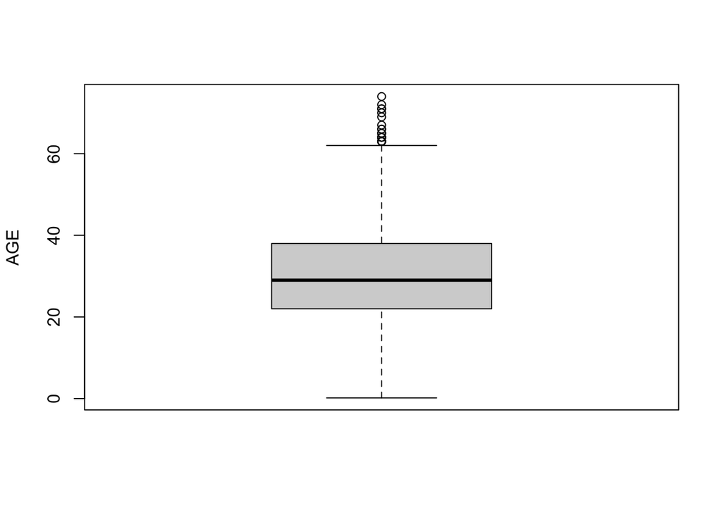

```r
boxplot(ds$age, ylab="AGE")
```

```r
sort(boxplot.stats(ds$age)$out)
```

```
##  [1] 63 63 63 63 63 63 63 64 64 64 64 64 64 65 65 65 66 66 67 69 70 71 71 72 74
```

Tras ver los datos, parecen edades con sentido. Observamos que el valor máximo es 74 y el mínimo 63 para aquellos valores que sobresalen en la distribución de la población.

#### 3.2.2 Fare

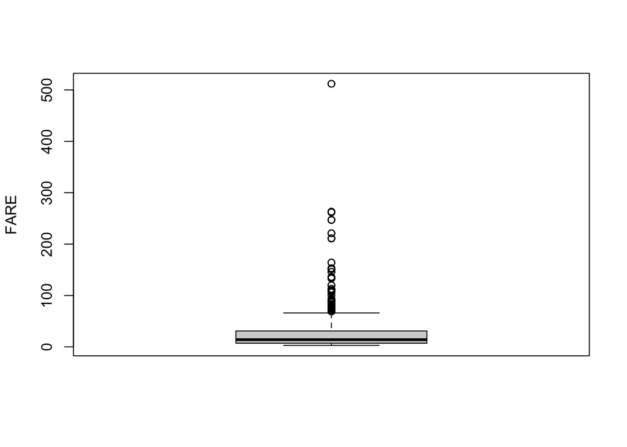

```r
boxplot(ds$fare, ylab="FARE")
```

Para la variable `fare` si encontramos valores realmente extremos. Vemos que al tratarse de un primer viaje no todos los pasajeros pagaron lo mismo. De hecho el salto con respecto a la media es significativo. Estos valores extremos es interesante conservarlos pues destaca la jerarquía social de la persona a bordo y seguramente nos sea interesante de cara a saber quienes sobrevivieron.

Con esta tabla podemos ver cuantas personas pagaron cada cantidad de dinero.

```r
table(sort(boxplot.stats(ds$fare)$out))
```

```
##
##    69.06    69.11       71  71.0508     73.1   75.041    75.05   76.051
##        2       11        2        2        7        2        2        2
##  76.1407  77.0509  77.1902  78.0504    78.17       79    79.04    79.13
##        3        2        3        2        3        1        4        3
##       80  81.1702  82.0305  82.0504  83.0302  83.0906     86.1  89.0201
##        3        3        2        2        6        2        3        2
##       90  91.0107     93.1      100 106.0806   108.18 110.1708 113.0506
##        3        2        4        2        3        3        4        3
##      120   133.13    134.1 135.1208 136.1507 146.1005   151.16 153.0903
##        4        2        5        3        2        3        6        3
## 164.1704 211.0609    211.1 211.6009 221.1507 247.1005 247.1006 262.0706
##        4        3        5        1        4        3        5        7
##      263 512.0607
##        6        4
```

#### 3.2.3 Sibsp

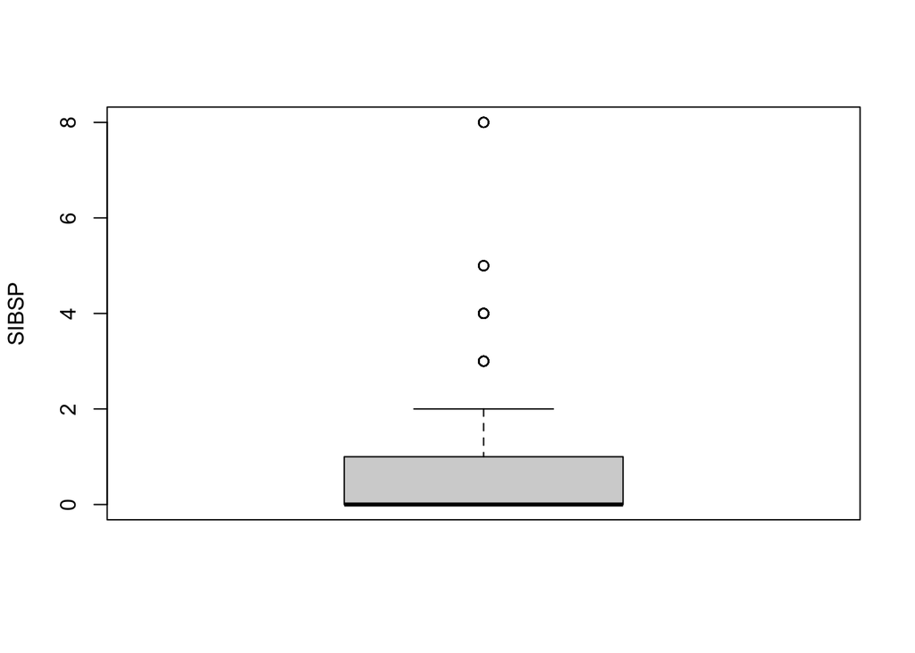

```r
boxplot(ds$sibsp, ylab="SIBSP")
```

```r
table(sort(boxplot.stats(ds$sibsp)$out))
```

```
##
##  3  4  5  8
## 20 22  6  9
```

Recordemos, la variable `sibsp` indica número de esposas/hermanos a bordo. Por lo tanto si encontramos el valor **3** deberíamos encontrar valores múltiplos de 4 en el dataset. Contando manualmente mi razonamiento parece cierto en los grupos de **3** hermanos, de **5** y de **8**. Sin embargo para **4** falla. Así que puede ser un error, o puede ser que fueran 3 hermanos + 1 pareja. Y cuando le preguntasen a dicha pareja respondiese con 1.

Deducimos que la mayoría de pasajeros del titanic no viajaban ni con hermanos ni con parejas.

#### 3.2.4 Parch

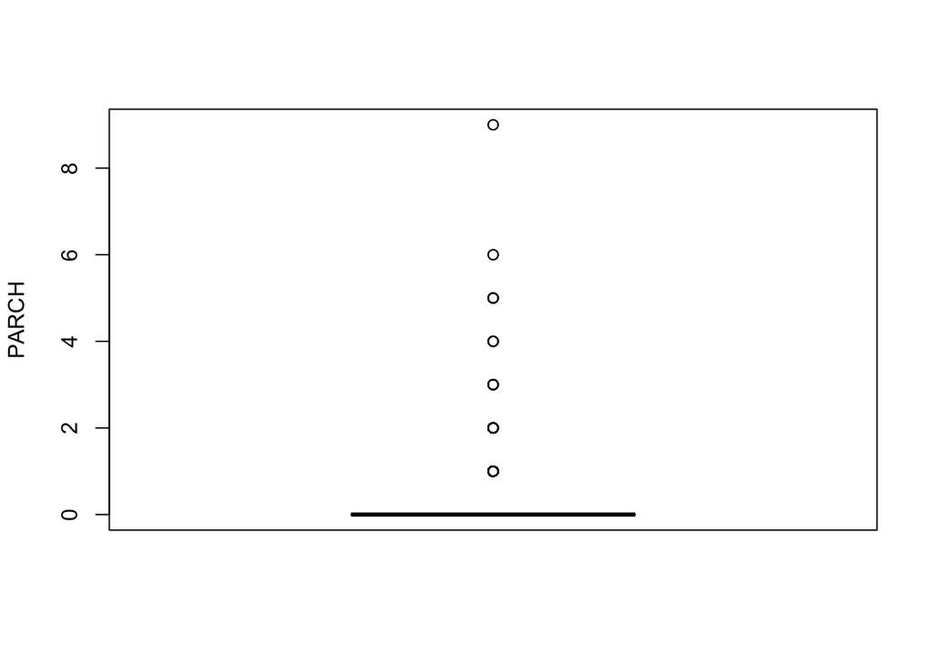

```r
boxplot(ds$parch, ylab="PARCH")
```

```r
table(sort(boxplot.stats(ds$parch)$out))
```

```
##
##   1   2   3   4   5   6   9
## 170 113   8   6   6   2   2
```

En el caso de la variable `parch` es el número de padres/hijos a bordo. Tampoco vamos a eliminar los outliers pues parecen tener sentido. Observamos que la mayoría de pasajeros del Titanic no tenían ni padres ni hijos a bordo.

## 4. Análisis de los datos.

### 4.1. Selección de los grupos de datos que se quieren comparar/analizar.

A continuación elegiremos qué datos utilizaremos, qué datos eliminaremos y si es necesario crear nuevas variables para llevar a cabo nuestro análisis.

#### 4.1.1. Eliminación de variables.

Descartaremos de nuestro dataset las variables **name** y **ticketno** ya que no aportan información de interés. En el caso de **ticketno**, podría dar información respecto a si el sujeto es pasajero o miembro de la tripulación, pero el mismo dato se puede obtener de la variable **fare** que sí es de interés para nuestro análisis.

```r
ds = select(ds, -name, -ticketno)
str(ds)
```

```
## 'data.frame':    2207 obs. of  9 variables:
##  $ gender  : Factor w/ 2 levels "female","male": 2 2 2 1 1 2 2 1 2 2 ...
##  $ age     : num  42 13 16 39 16 25 30 28 27 20 ...
##  $ class   : Factor w/ 7 levels "1st","2nd","3rd",..: 3 3 3 3 3 3 2 2 3 3 ...
##  $ embarked: Factor w/ 4 levels "B","C","Q","S": 4 4 4 4 4 4 2 2 2 4 ...
##  $ country : Factor w/ 48 levels "Argentina","Australia",..: 45 45 45 15 31 45 17 17 27 16 ...
##  $ fare    : num  7.11 20.05 20.05 20.05 7.13 ...
##  $ sibsp   : int  0 0 1 1 0 0 1 1 0 0 ...
##  $ parch   : int  0 2 1 1 0 0 0 0 0 0 ...
##  $ survived: Factor w/ 2 levels "no","yes": 1 1 1 2 2 2 1 2 2 2 ...
```

#### 4.1.2. Generación de nuevas variables.

Generaremos una nueva variable que se corresponde a la **edad discretizada**.

```r
#Edad discretizada con un método simple de intervalos de igual amplitud.
summary(ds[,"age"])
```

```
##    Min. 1st Qu.  Median    Mean 3rd Qu.    Max.
##  0.1667 22.0000 29.0000 30.4318 38.0000 74.0000
```

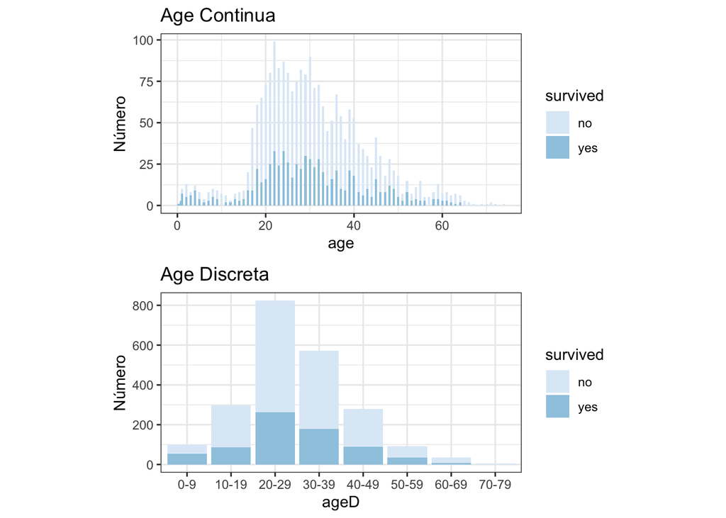

```r
ds["ageD"] = cut(ds$age, breaks = c(0,10,20,30,40,50,60,70,100), labels = c("0-9", "10-19", "20-29", "30-39","40-49","50-59","60-69","70-79"))
g1 <- ggplot(ds, aes(x = age, fill=survived))+geom_bar(width=0.5)+scale_fill_brewer(palette="Blues")+theme(aspect.ratio = 0.5)+ggtitle("Age Continua")+ylab("Número")
g2 = ggplot(ds, aes(x = ageD, fill=survived)) + geom_bar()+scale_fill_brewer(palette="Blues")+theme(aspect.ratio = 0.5)+ggtitle("Age Discreta")+ylab("Número")
gridExtra::grid.arrange(g1, g2, ncol=1)
```

A continuación crearemos una variable que nos dirá si el sujeto es **miembro de la tripulación o pasajero**.

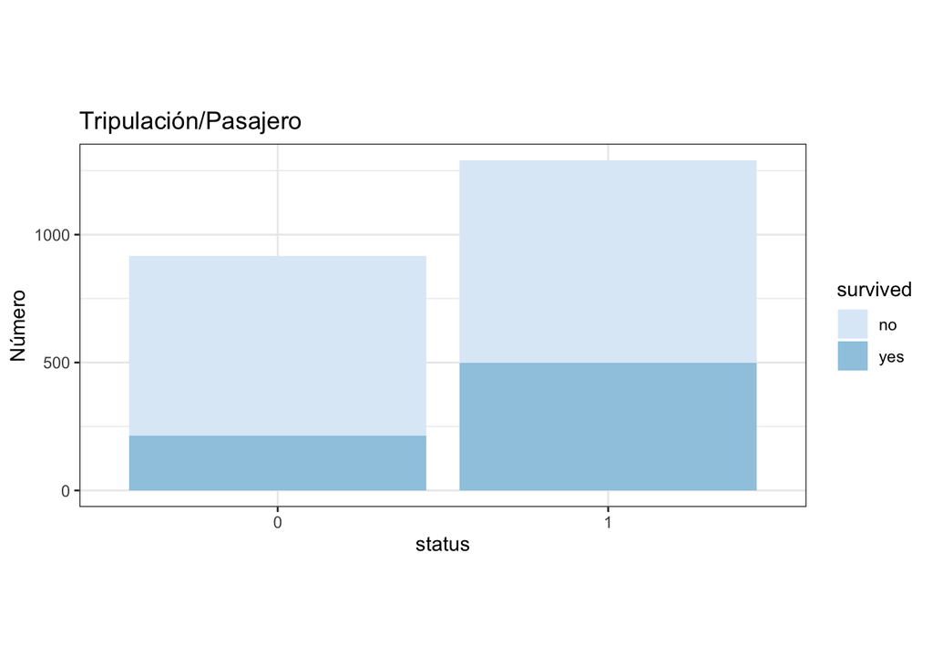

```r
#Nueva variable para identificar pasajeros y miembros de la tripulación
ds$status = ds$fare
ds$status[is.na(ds$status)] = 0
ds$status[ds$status != 0] = 1
ds$status = as.factor(ds$status)
g3 = ggplot(ds, aes(x = status, fill=survived))+ geom_bar()+scale_fill_brewer(palette="Blues")+theme(aspect.ratio = 0.5)+ggtitle("Tripulación/Pasajero")+ylab("Número")
g3
```

Por último, generaremos una variable que nos indicará el tamaño de la familia de cada sujeto.

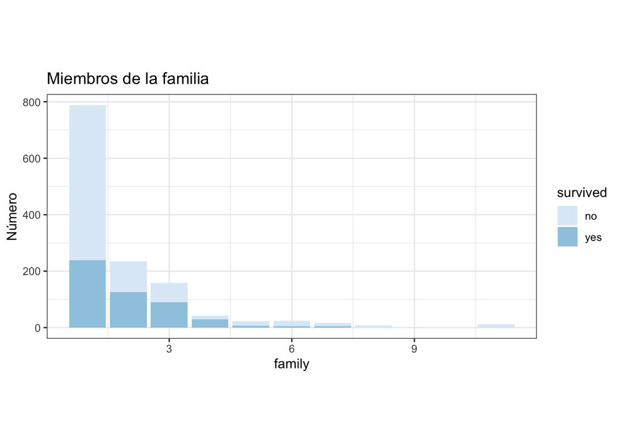

```r
#Nueva variable para calcular el tamaño de la familia entre los pasajeros
ds$sibspN = as.numeric(ds$sibsp)
ds$parchN = as.numeric(ds$parch)
ds$family = ds$sibspN + ds$parchN +1
ds = select(ds, -sibspN, -parchN)
g4 = ggplot(ds,aes(x=family,fill=survived))+geom_bar()+scale_fill_brewer(palette="Blues")+theme(aspect.ratio = 0.5)+ggtitle("Miembros de la familia")+ylab("Número")
g4
```

#### 4.1.3. Selección del grupo de datos para el análisis.

Una vez tenemos el dataset con las variables que necesitamos, seleccionaremos los grupos de datos que puede ser interesante analizar:

- Pasajeros que hayan sobrevivido en función de la edad: **survived** y **age**/**ageD**
- Pasajeros que hayan sobrevivido en función del genero: **survived** y **genre**
- Pasajeros que hayan sobrevivido en función del puerto de embarque: **survived** y **embarked**
- Pasajeros que hayan sobrevivido en función del país de origen: **survived** y **country**
- Pasajeros que hayan sobrevivido en función de la clase: **survived** y **class**
- Pasajeros que hayan sobrevivido en función del número de familiares: **survived** y **sibsp**
- Pasajeros que hayan sobrevivido en función del número de familiares: **survived** y **parch**
- Pasajeros que hayan sobrevivido en función del tamaño de la familia con la que viajaban: **survived** y **family**
- Categoría del billete en función del puerto de embarque: **class** y **embarked**
- Categoría del billete en función del país de origen: **class** y **country** Con los datos anteriores, al llevar a cabo el análisis se verá si resulta de interés hacer alguna combinación de las variables anteriores

### 4.2. Comprobación de la normalidad y homogeneidad de la varianza.

A la hora de realizar un análisis de normalidad y homgeneidad de la varianza, empezaremos con un análisis descriptivo de los datos:

```r
summary(ds)
```

```
##     gender          age                       class     embarked
##  female: 489   Min.   : 0.1667   1st             :324   B: 197
##  male  :1718   1st Qu.:22.0000   2nd             :284   C: 271
##                Median :29.0000   3rd             :709   Q: 123
##                Mean   :30.4318   deck crew       : 66   S:1616
##                3rd Qu.:38.0000   engineering crew:324
##                Max.   :74.0000   restaurant staff: 69
##                                  victualling crew:431
##           country          fare             sibsp            parch
##  England      :1206   Min.   :  3.030   Min.   :0.0000   Min.   :0.0000
##  United States: 264   1st Qu.:  7.181   1st Qu.:0.0000   1st Qu.:0.0000
##  Ireland      : 137   Median : 14.090   Median :0.0000   Median :0.0000
##  Sweden       : 105   Mean   : 33.405   Mean   :0.4996   Mean   :0.3856
##  Lebanon      :  71   3rd Qu.: 31.061   3rd Qu.:1.0000   3rd Qu.:0.0000
##  Finland      :  54   Max.   :512.061   Max.   :8.0000   Max.   :9.0000
##  (Other)      : 370   NA's   :916       NA's   :900      NA's   :900
##  survived        ageD     status       family
##  no :1496   20-29  :824   0: 916   Min.   : 1.000
##  yes: 711   30-39  :572   1:1291   1st Qu.: 1.000
##             10-19  :299            Median : 1.000
##             40-49  :280            Mean   : 1.885
##             0-9    :100            3rd Qu.: 2.000
##             50-59  : 93            Max.   :11.000
##             (Other): 39            NA's   :900
```

A partir de los datos obtenidos, podemos calcular la normalidad de los tres atributos numéricos: **age**, **fare**, y **family**. Para ello utilizaremos el test de Saphiro-Wilk:

```r
shapiro.test(ds$age)
```

```
##
##  Shapiro-Wilk normality test
##
## data:  ds$age
## W = 0.98054, p-value < 2.2e-16
```

```r
shapiro.test(ds$fare)
```

```
##
##  Shapiro-Wilk normality test
##
## data:  ds$fare
## W = 0.52374, p-value < 2.2e-16
```

```r
shapiro.test(ds$family)
```

```
##
##  Shapiro-Wilk normality test
##
## data:  ds$family
## W = 0.60956, p-value < 2.2e-16
```

A continuación se analiza el valor de p. En el caso de que sea mayor que el nivel de significancia, se acepta la hipótesis nula y se concluye que la variable tiene una distribución normal. En nuestro caso todas las variables analizadas presentan valores inferiores al nivel de signficancia, por lo que podemos concluir con un 95% de confianza que no presentan una distribución normal. Veámoslo a continuación de forma gráfica:

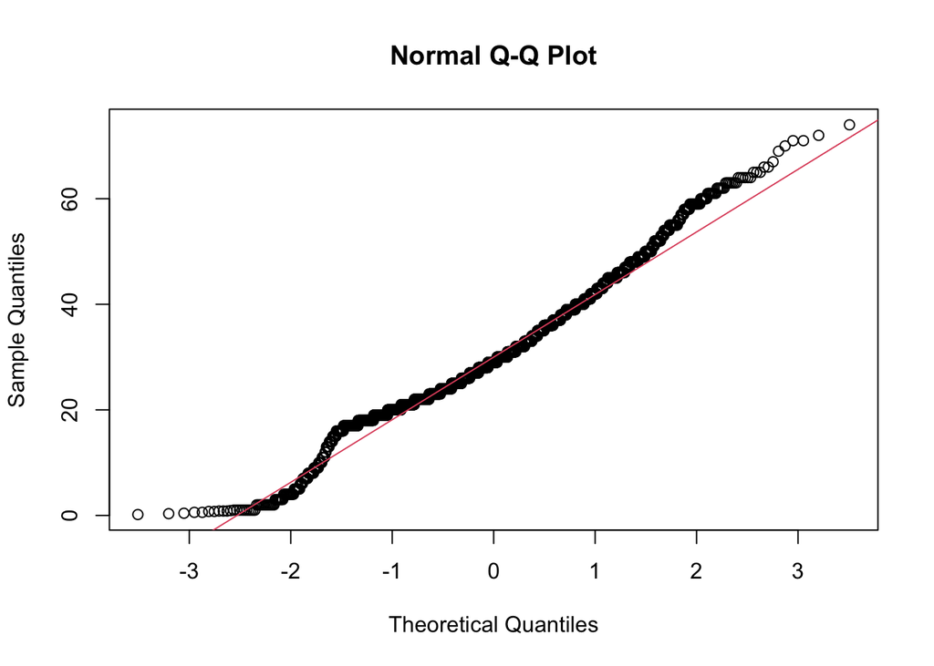

```r
qqnorm(ds$age);qqline(ds$age, col = 2)
```

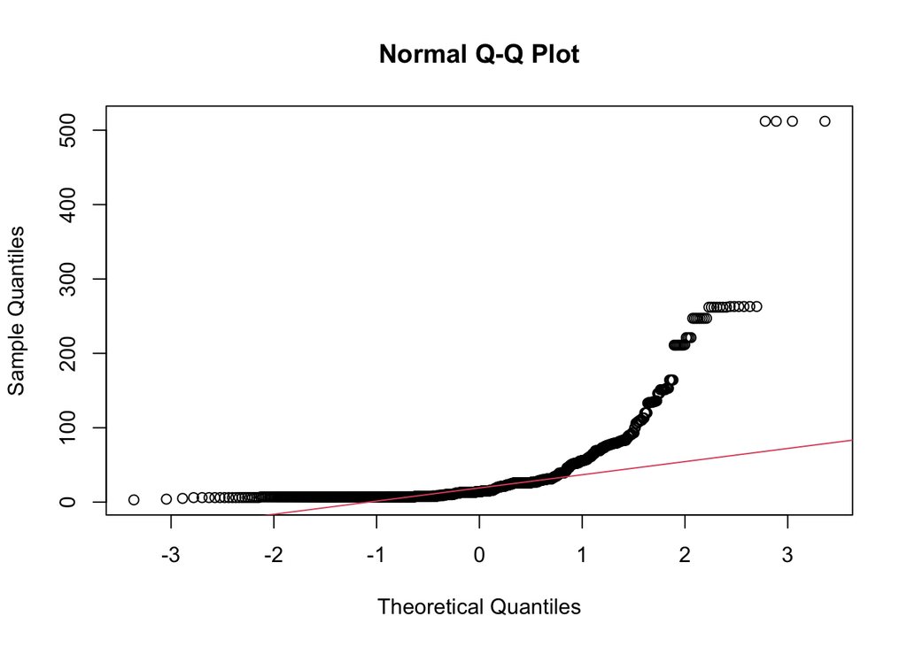

```r
qqnorm(ds$fare);qqline(ds$fare, col = 2)
```

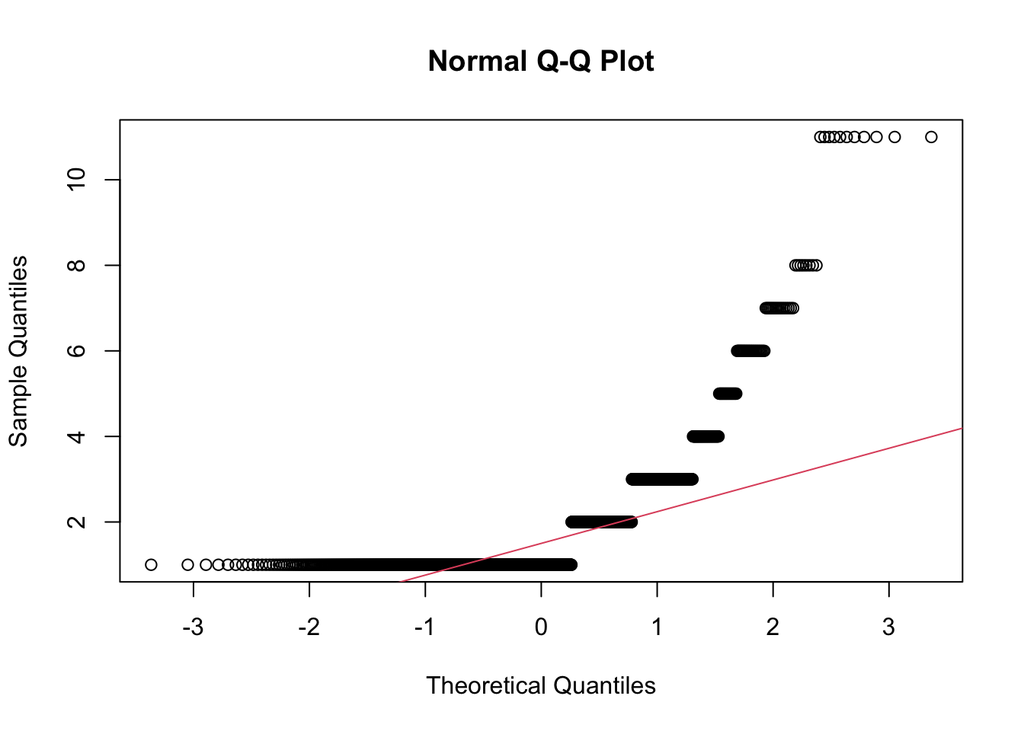

```r
qqnorm(ds$family);qqline(ds$family, col = 2)
```

```r
fligner.test(age ~ survived, data = ds)
```

```
##
##  Fligner-Killeen test of homogeneity of variances
##
## data:  age by survived
## Fligner-Killeen:med chi-squared = 3.2538, df = 1, p-value = 0.07126
```

```r
fligner.test(fare ~ survived, data = ds)
```

```
##
##  Fligner-Killeen test of homogeneity of variances
##
## data:  fare by survived
## Fligner-Killeen:med chi-squared = 138.14, df = 1, p-value < 2.2e-16
```

```r
fligner.test(family ~ survived, data = ds)
```

```
##
##  Fligner-Killeen test of homogeneity of variances
##
## data:  family by survived
## Fligner-Killeen:med chi-squared = 31.783, df = 1, p-value = 1.724e-08
```

Una vez ejecutados los test, podemos aceptar la hipótesis nula en aquellos casos en los que el valor de p sea mayor que el valor de significancia (0,05). Por lo tanto, para la variable **age**, con p-valor>0,05 diremos con un 95% de confianza que su varianza es la misma tanto para los supervivientes como para los que no. Siguiendo el mismo razonamiento, para **fare** y **family**, con p-valor<=0,05, afirmaremos que las varianzas de estas variables son diferentes para los dos grupos de la variable “survived”.

### 4.3. Aplicación de pruebas estadísticas para comparar los grupos de datos.

Nos interesa realizar un estudio de cómo se relacionan las variables para determinar si una persona sobrevive o no al hundimiento del Titanic. Para ello se hará uso de la variable dicotómica `survived`. Sería interesante analizar si existe asociación entre la variable dependiente `survived` y las variables explicativas que queramos usar de cara a la construcción del modelo predictivo de regresión logística.

```r
chisq.test(table(ds$survived, ds$gender))
```

```
##
##  Pearson's Chi-squared test with Yates' continuity correction
##
## data:  table(ds$survived, ds$gender)
## X-squared = 485.87, df = 1, p-value < 2.2e-16
```

```r
chisq.test(table(ds$survived, ds$age))
```

```
##
##  Pearson's Chi-squared test
##
## data:  table(ds$survived, ds$age)
## X-squared = 110.3, df = 78, p-value = 0.009436
```

```r
chisq.test(table(ds$survived, ds$class))
```

```
##
##  Pearson's Chi-squared test
##
## data:  table(ds$survived, ds$class)
## X-squared = 252.24, df = 6, p-value < 2.2e-16
```

```r
chisq.test(table(ds$survived, ds$embarked))
```

```
##
##  Pearson's Chi-squared test
##
## data:  table(ds$survived, ds$embarked)
## X-squared = 90.351, df = 3, p-value < 2.2e-16
```

```r
chisq.test(table(ds$survived, ds$country))
```

```
##
##  Pearson's Chi-squared test
##
## data:  table(ds$survived, ds$country)
## X-squared = 189.4, df = 47, p-value < 2.2e-16
```

```r
chisq.test(table(ds$survived, ds$fare))
```

```
##
##  Pearson's Chi-squared test
##
## data:  table(ds$survived, ds$fare)
## X-squared = 556.14, df = 275, p-value < 2.2e-16
```

```r
chisq.test(table(ds$survived, ds$sibsp))
```

```
##
##  Pearson's Chi-squared test
##
## data:  table(ds$survived, ds$sibsp)
## X-squared = 43.257, df = 6, p-value = 1.037e-07
```

```r
chisq.test(table(ds$survived, ds$parch))
```

```
##
##  Pearson's Chi-squared test
##
## data:  table(ds$survived, ds$parch)
## X-squared = 53.565, df = 7, p-value = 2.867e-09
```

```r
chisq.test(table(ds$survived, ds$family))
```

```
##
##  Pearson's Chi-squared test
##
## data:  table(ds$survived, ds$family)
## X-squared = 102.78, df = 8, p-value < 2.2e-16
```

Ahora bien, de estas variables que hemos detectado que pueden afectar a la supervivencia, vamos a analizar cómo se comportan a la hora de construir el modelo.

```r
model_gender <- glm(formula = ds$survived~factor(ds$gender), data = ds, family = binomial)
summary(model_gender)
```

```
##
## Call:
## glm(formula = ds$survived ~ factor(ds$gender), family = binomial,
##     data = ds)
##
## Deviance Residuals:
##     Min       1Q   Median       3Q      Max
## -1.6278  -0.6772  -0.6772   0.7862   1.7806
##
## Coefficients:
##                       Estimate Std. Error z value Pr(>|z|)
## (Intercept)             1.0158     0.1024   9.924   <2e-16 ***
## factor(ds$gender)male  -2.3718     0.1185 -20.009   <2e-16 ***
## ---
## Signif. codes:  0 '***' 0.001 '**' 0.01 '*' 0.05 '.' 0.1 ' ' 1
##
## (Dispersion parameter for binomial family taken to be 1)
##
##     Null deviance: 2774.1  on 2206  degrees of freedom
## Residual deviance: 2308.8  on 2205  degrees of freedom
## AIC: 2312.8
##
## Number of Fisher Scoring iterations: 4
```

Vamos a calcular los OR para saber si su efecto sobre el modelo es un factor protector o no.

```r
exp(cbind(coef(model_gender), confint(model_gender)))
```

```
##                                       2.5 %    97.5 %
## (Intercept)           2.76153846 2.26626223 3.3863167
## factor(ds$gender)male 0.09331272 0.07375952 0.1174152
```

Vamos a construir el modelo en función de todas las variable que consideramos afectan al modelo.

```r
model_gender_class_embarked <- glm(formula = ds$survived~factor(ds$gender)+factor(ds$class)+factor(ds$embarked), data = ds, family = binomial)
summary(model_gender_class_embarked)
```

```
##
## Call:
## glm(formula = ds$survived ~ factor(ds$gender) + factor(ds$class) +
##     factor(ds$embarked), family = binomial, data = ds)
##
## Deviance Residuals:
##     Min       1Q   Median       3Q      Max
## -2.3067  -0.6722  -0.4598   0.7183   2.5893
##
## Coefficients:
##                                  Estimate Std. Error z value Pr(>|z|)
## (Intercept)                        1.6285     0.2825   5.765 8.18e-09 ***
## factor(ds$gender)male             -2.5958     0.1447 -17.933  < 2e-16 ***
## factor(ds$class)2nd               -0.7487     0.2074  -3.610 0.000306 ***
## factor(ds$class)3rd               -1.6130     0.1827  -8.831  < 2e-16 ***
## factor(ds$class)deck crew          1.4102     0.3119   4.521 6.16e-06 ***
## factor(ds$class)engineering crew  -0.5529     0.2086  -2.651 0.008025 **
## factor(ds$class)restaurant staff  -2.6339     0.6274  -4.198 2.69e-05 ***
## factor(ds$class)victualling crew  -0.6899     0.2045  -3.374 0.000740 ***
## factor(ds$embarked)C               0.9594     0.2767   3.467 0.000526 ***
## factor(ds$embarked)Q               0.3864     0.3266   1.183 0.236761
## factor(ds$embarked)S               0.2846     0.2097   1.358 0.174600
## ---
## Signif. codes:  0 '***' 0.001 '**' 0.01 '*' 0.05 '.' 0.1 ' ' 1
##
## (Dispersion parameter for binomial family taken to be 1)
##
##     Null deviance: 2774.1  on 2206  degrees of freedom
## Residual deviance: 2098.0  on 2196  degrees of freedom
## AIC: 2120
##
## Number of Fisher Scoring iterations: 5
```

No obstante, primero vamos a calcular los OR para todas las variables seleccionadas con el objetivo de saber si su efecto sobre el modelo es un factor protector o no.

```r
exp(cbind(coef(model_gender_class_embarked), confint(model_gender_class_embarked)))
```

```
##                                                  2.5 %     97.5 %
## (Intercept)                      5.09633236 2.91974411 8.84795951
## factor(ds$gender)male            0.07458670 0.05590166 0.09863276
## factor(ds$class)2nd              0.47296573 0.31428726 0.70906925
## factor(ds$class)3rd              0.19928724 0.13885631 0.28427891
## factor(ds$class)deck crew        4.09689021 2.24292442 7.64588768
## factor(ds$class)engineering crew 0.57527269 0.38163616 0.86502808
## factor(ds$class)restaurant staff 0.07179801 0.01664504 0.21089577
## factor(ds$class)victualling crew 0.50163365 0.33571984 0.74868484
## factor(ds$embarked)C             2.61023028 1.52499576 4.51696074
## factor(ds$embarked)Q             1.47173377 0.77664692 2.79788891
## factor(ds$embarked)S             1.32927079 0.88905584 2.02597687
```

Por curiosidad vamos a crear un nuevo modelo con una de las variables anteriormente descartadas para observar su comportamiento.

```r
model_fail <- glm(formula = ds$survived~factor(ds$gender)+factor(ds$class)+factor(ds$embarked)+factor(ds$sibsp)+factor(ds$parch), data = ds, family = binomial)
summary(model_fail)
```

```
##
## Call:
## glm(formula = ds$survived ~ factor(ds$gender) + factor(ds$class) +
##     factor(ds$embarked) + factor(ds$sibsp) + factor(ds$parch),
##     family = binomial, data = ds)
##
## Deviance Residuals:
##     Min       1Q   Median       3Q      Max
## -2.2178  -0.6404  -0.4614   0.6023   2.5606
##
## Coefficients:
##                        Estimate Std. Error z value Pr(>|z|)
## (Intercept)            -13.5322   785.5331  -0.017 0.986256
## factor(ds$gender)male   -2.5348     0.1594 -15.903  < 2e-16 ***
## factor(ds$class)2nd     -0.8116     0.2128  -3.814 0.000137 ***
## factor(ds$class)3rd     -1.5180     0.1856  -8.179 2.85e-16 ***
## factor(ds$embarked)C    15.9023   785.5331   0.020 0.983849
## factor(ds$embarked)Q    15.4729   785.5332   0.020 0.984285
## factor(ds$embarked)S    15.3985   785.5331   0.020 0.984360
## factor(ds$sibsp)1       -0.1390     0.1806  -0.770 0.441507
## factor(ds$sibsp)2       -0.1093     0.4212  -0.260 0.795218
## factor(ds$sibsp)3       -1.5840     0.5993  -2.643 0.008213 **
## factor(ds$sibsp)4       -1.6891     0.7197  -2.347 0.018939 *
## factor(ds$sibsp)5      -16.2745   833.1430  -0.020 0.984415
## factor(ds$sibsp)8      -16.4835   671.4771  -0.025 0.980415
## factor(ds$parch)1        0.8870     0.2340   3.791 0.000150 ***
## factor(ds$parch)2        0.6356     0.2910   2.184 0.028964 *
## factor(ds$parch)3        0.1065     0.8487   0.125 0.900168
## factor(ds$parch)4       -1.9536     1.1880  -1.644 0.100079
## factor(ds$parch)5       -1.4584     1.1495  -1.269 0.204568
## factor(ds$parch)6      -15.8096  1425.1340  -0.011 0.991149
## factor(ds$parch)9      -15.8096  1425.1340  -0.011 0.991149
## ---
## Signif. codes:  0 '***' 0.001 '**' 0.01 '*' 0.05 '.' 0.1 ' ' 1
##
## (Dispersion parameter for binomial family taken to be 1)
##
##     Null deviance: 1739.1  on 1306  degrees of freedom
## Residual deviance: 1190.8  on 1287  degrees of freedom
##   (900 observations deleted due to missingness)
## AIC: 1230.8
##
## Number of Fisher Scoring iterations: 15
```

```r
model_fail_family <- glm(formula = ds$survived~factor(ds$gender)+factor(ds$class)+factor(ds$embarked)+factor(ds$family), data = ds, family = binomial)
summary(model_fail_family)
```

```
##
## Call:
## glm(formula = ds$survived ~ factor(ds$gender) + factor(ds$class) +
##     factor(ds$embarked) + factor(ds$family), family = binomial,
##     data = ds)
##
## Deviance Residuals:
##     Min       1Q   Median       3Q      Max
## -2.3550  -0.6338  -0.4576   0.5973   2.6663
##
## Coefficients:
##                        Estimate Std. Error z value Pr(>|z|)
## (Intercept)           -13.49276  784.42835  -0.017  0.98628
## factor(ds$gender)male  -2.55713    0.16017 -15.965  < 2e-16 ***
## factor(ds$class)2nd    -0.84225    0.21324  -3.950 7.82e-05 ***
## factor(ds$class)3rd    -1.54298    0.18626  -8.284  < 2e-16 ***
## factor(ds$embarked)C   15.93146  784.42834   0.020  0.98380
## factor(ds$embarked)Q   15.42464  784.42837   0.020  0.98431
## factor(ds$embarked)S   15.38904  784.42833   0.020  0.98435
## factor(ds$family)2      0.03671    0.19641   0.187  0.85172
## factor(ds$family)3      0.62770    0.21923   2.863  0.00419 **
## factor(ds$family)4      0.81212    0.41592   1.953  0.05087 .
## factor(ds$family)5     -1.32182    0.57035  -2.318  0.02047 *
## factor(ds$family)6     -1.31979    0.61764  -2.137  0.03261 *
## factor(ds$family)7     -0.73633    0.65163  -1.130  0.25848
## factor(ds$family)8    -15.71807  715.02726  -0.022  0.98246
## factor(ds$family)11   -15.86527  605.94303  -0.026  0.97911
## ---
## Signif. codes:  0 '***' 0.001 '**' 0.01 '*' 0.05 '.' 0.1 ' ' 1
##
## (Dispersion parameter for binomial family taken to be 1)
##
##     Null deviance: 1739.1  on 1306  degrees of freedom
## Residual deviance: 1194.5  on 1292  degrees of freedom
##   (900 observations deleted due to missingness)
## AIC: 1224.5
##
## Number of Fisher Scoring iterations: 15
```

Observamos que si introducimos la variable `family` en el modelo, realmente pierde eficacia el modelo y vemos un comportamiento similar al obtenido cuando agregamos las variables `parch` y `sibsp`. Podemos realizar el test de Hosman-Lemeshow para ver la bondad de ajuste.

```r
library(ResourceSelection)
```

```
## ResourceSelection 0.3-5   2019-07-22
```

```r
hoslem.test(ds$survived, fitted(model_gender_class_embarked))
```

```
##
##  Hosmer and Lemeshow goodness of fit (GOF) test
##
## data:  ds$survived, fitted(model_gender_class_embarked)
## X-squared = 2207, df = 8, p-value < 2.2e-16
```

También podemos dibujar la curva **ROC** del modelo.

```r
# ROC se encuentra en el paquete pROC
library(pROC)
r_c=roc(ds$survived, predict(model_gender_class_embarked, ds, type="response") , data=ds)
```

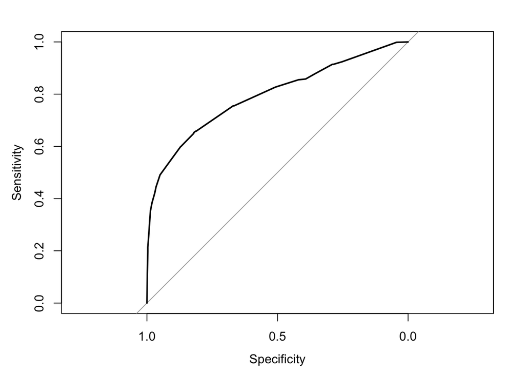

```r
plot(r_c)
```

```r
auc(r_c)
```

```
## Area under the curve: 0.7947
```

Vemos que el área debajo de la curva del modelo `model_gender_class_embarked` adquiere el valor de 0.7947 por lo tanto la capacidad del modelo para predecir supervivencia es bastante buena. Casi un 80%.

También queremos analizar la correlación existente entre la variables **class** y **embarked** y **class** y **country**. Para ello haremos uso de un mapa de calor.

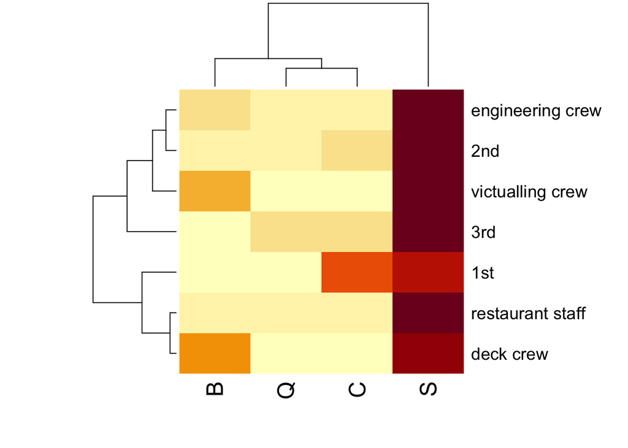

```r
data_cor_class_embarked <- as.matrix(table(ds$class, ds$embarked))
data_cor_class_country <- as.matrix(table(ds$class, ds$country))
heatmap(data_cor_class_embarked)
```

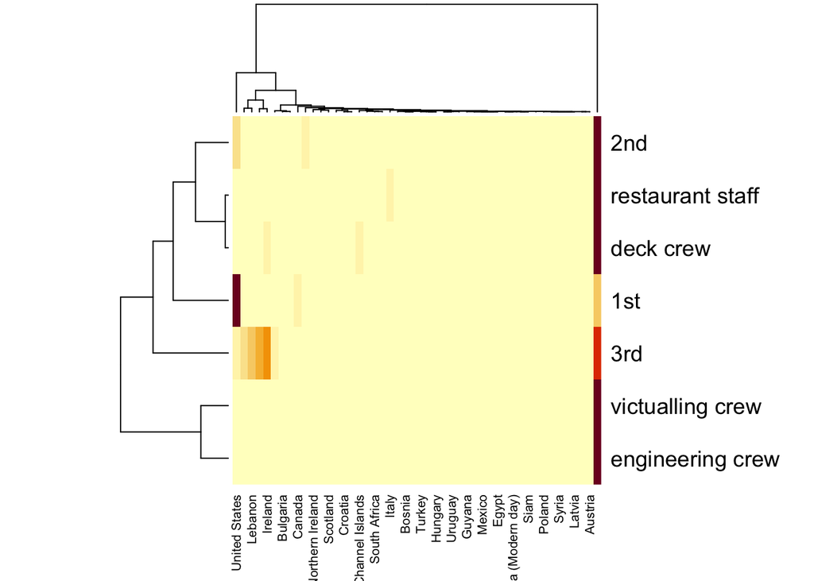

```r
heatmap(data_cor_class_country)
```

Parece que existe una correlación entre el puerto de embarque **C** y ser de primera clase **1st**. Luego también se ve claramente una correlación entre el puerto de embarque en **B** y formar parte de la tripulación **victualling** y **deck**. Podemos decir que la correlación está siendo sesgada por el número de pasajeros que inician el viaje en **S**.

En el caso del análisis con respecto al pais de origen se destaca el hecho de formar parte de primera clase siendo estadounidense.

## 5. Representación de los resultados a partir de tablas y gráficas.

A continuación mostramos todas las gráficas de aquellas variables que hemos analizado respecto a la supervicencia en el hundimiento del titanic:

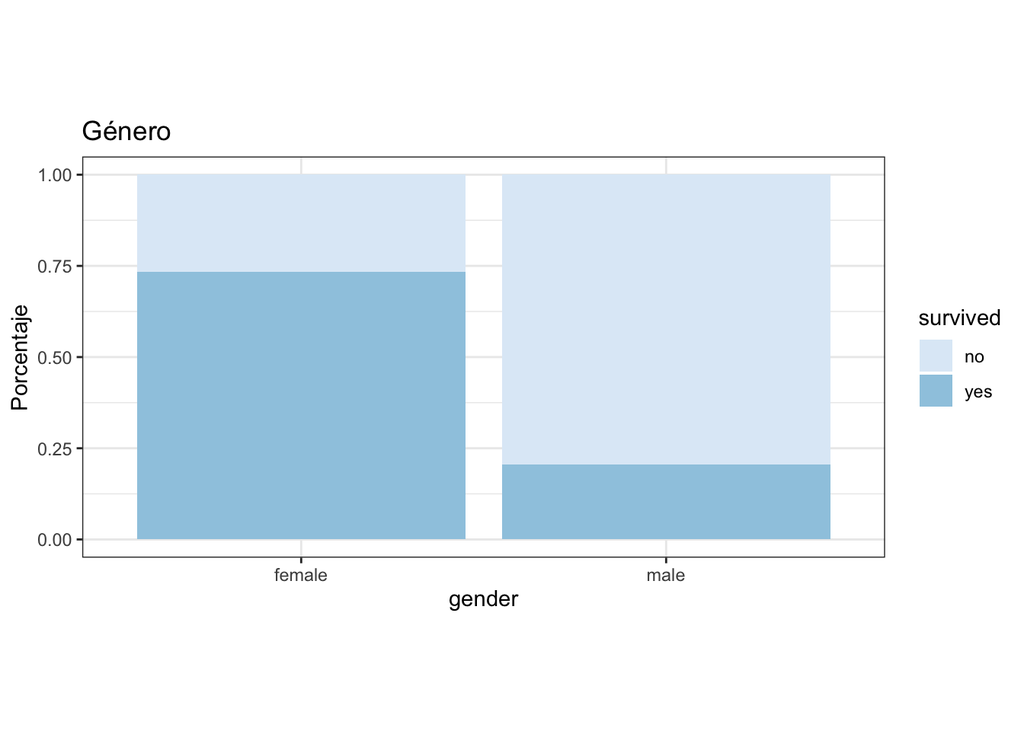

```r
ggplot(ds,aes(x=gender,fill=survived))+geom_bar(position = "fill")+scale_fill_brewer(palette="Blues")+theme(aspect.ratio = 0.5)+ggtitle("Género")+ylab("Porcentaje")
```

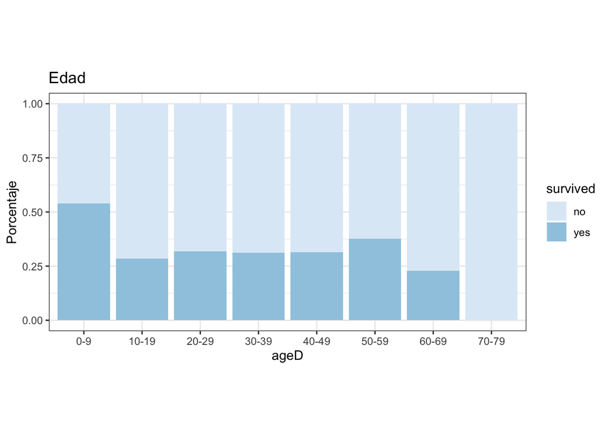

```r
ggplot(ds,aes(x=ageD,fill=survived))+geom_bar(position = "fill")+scale_fill_brewer(palette="Blues")+theme(aspect.ratio = 0.5)+ggtitle("Edad")+ylab("Porcentaje")
```

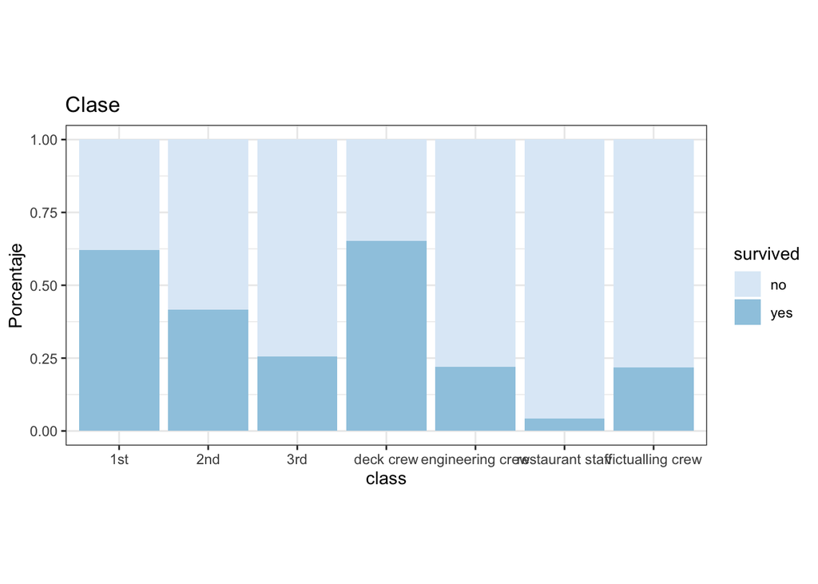

```r
ggplot(ds,aes(x=class,fill=survived))+geom_bar(position = "fill")+scale_fill_brewer(palette="Blues")+theme(aspect.ratio = 0.5)+ggtitle("Clase")+ylab("Porcentaje")
```

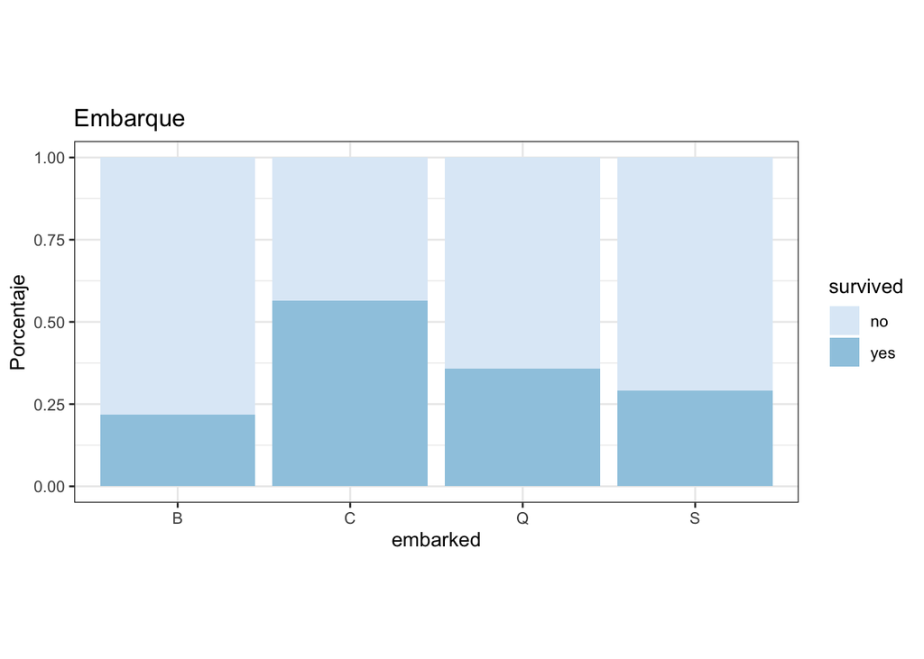

```r
ggplot(ds,aes(x=embarked,fill=survived))+geom_bar(position = "fill")+scale_fill_brewer(palette="Blues")+theme(aspect.ratio = 0.5)+ggtitle("Embarque")+ylab("Porcentaje")
```

[figure not shown]

```r
ggplot(ds,aes(x=country,fill=survived))+geom_bar(position = "fill")+scale_fill_brewer(palette="Blues")+theme(aspect.ratio = 0.5)+ggtitle("País")+ylab("Porcentaje")
```

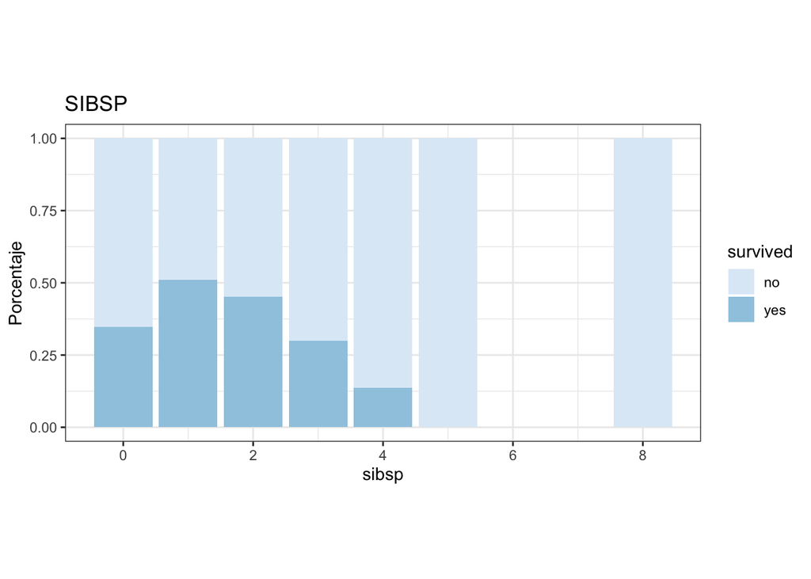

```r
ggplot(ds,aes(x=sibsp,fill=survived))+geom_bar(position = "fill")+scale_fill_brewer(palette="Blues")+theme(aspect.ratio = 0.5)+ggtitle("SIBSP")+ylab("Porcentaje")
```

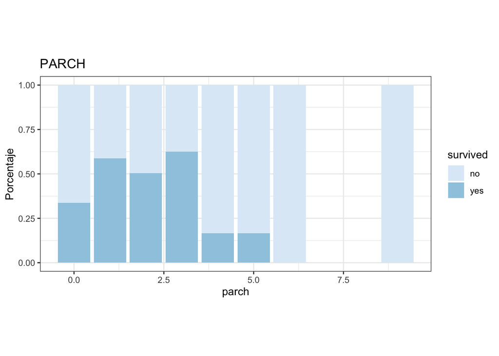

```r
ggplot(ds,aes(x=parch,fill=survived))+geom_bar(position = "fill")+scale_fill_brewer(palette="Blues")+theme(aspect.ratio = 0.5)+ggtitle("PARCH")+ylab("Porcentaje")
```

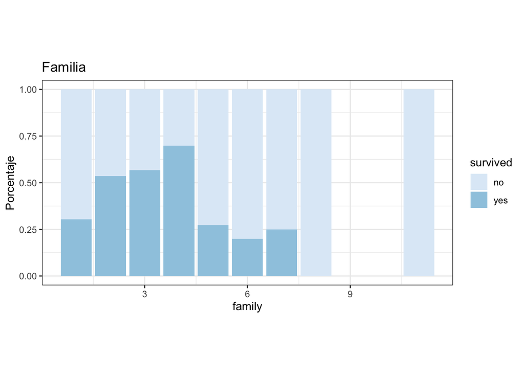

```r
ggplot(ds,aes(x=family,fill=survived))+geom_bar(position = "fill")+scale_fill_brewer(palette="Blues")+theme(aspect.ratio = 0.5)+ggtitle("Familia")+ylab("Porcentaje")
```

A continuación mostramos los mapas de calor generados que comparan la correlación entre la clase y el puerto de embarque así como el país de origen.

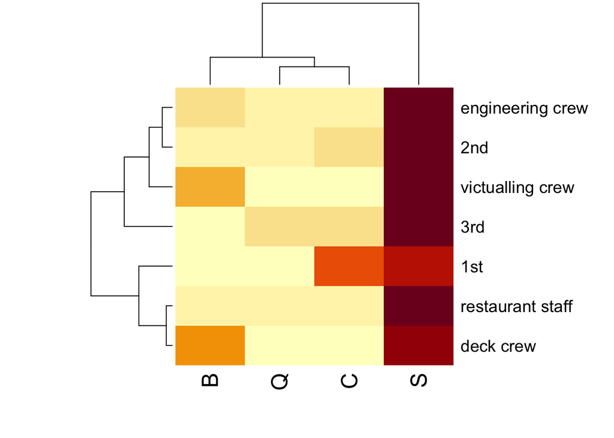

```r
heatmap(data_cor_class_embarked)
```

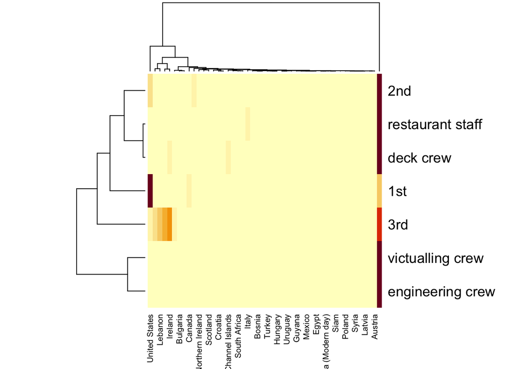

```r
heatmap(data_cor_class_country)
```

También se visualiza el resultado del modelo que mejor se comporta para los datos.

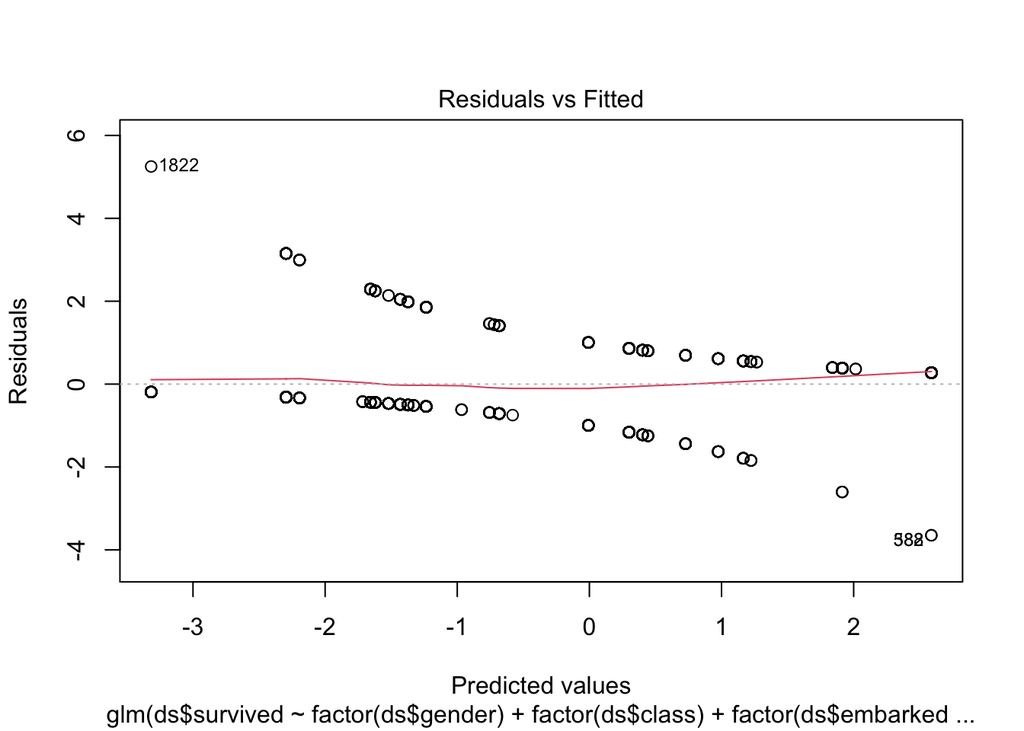

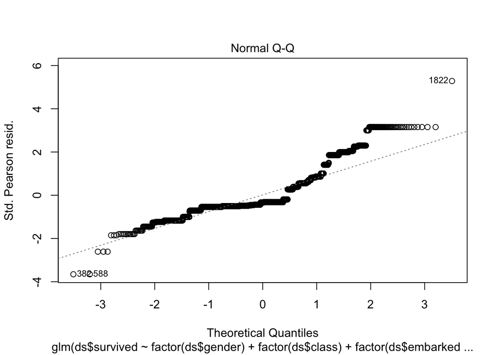

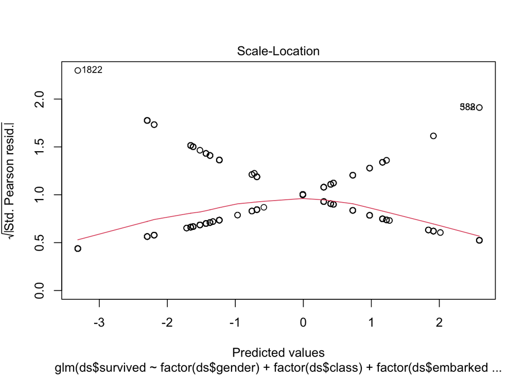

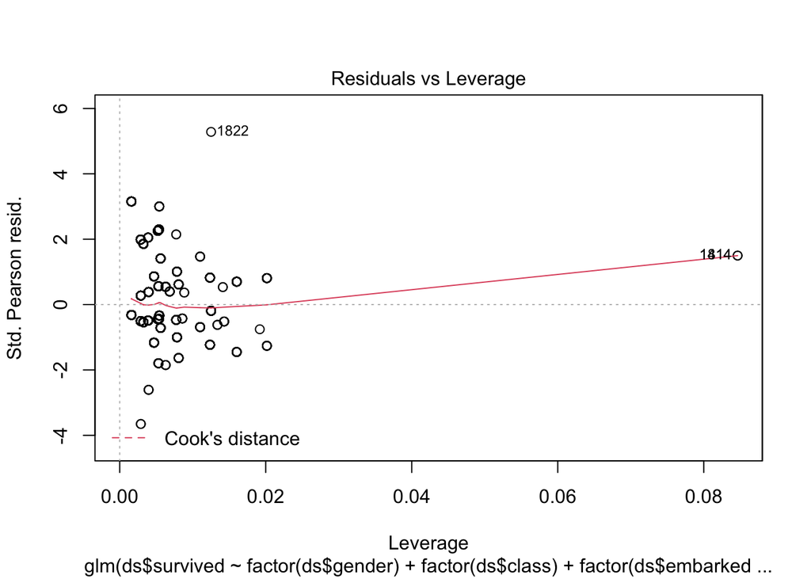

```r
plot(model_gender_class_embarked)
```

## 6. Resolución del problema.

A partir de los resultados obtenidos y de las gráficas mostradas en el apartado anterior podemos afirmar lo siguiente:

- Las variables que influyen de una forma estadísticamente significativa en las contrucción del modelo y por lo tanto en la supervivencia en el desastre histórico son `gender`, `class` y `embarked`.
- Las variables `age`, `sibsp`, `parch` y `family` no tienen gran impacto en la supervivencia.
- Existe una correlación entre el puerto de embarque **C** y ser de primera clase **1st**.
- Se ve claramente una correlación entre el puerto de embarque en **B** y formar parte de la tripulación **victualling** y **deck**. Aunque está siendo sesgada por la elevada proporción de pasajeros que inician el viaje en **S**.
- Se encuentra que la mayoría de individuos de primera clase son estadounidenses.

## 7. Exportar dataset resultante

```r
write.csv(ds, "./data/titanic_processed.csv", row.names = T)
```

## 8. Tabla contribuciones

| **Contribuciones** | **Firma** |
| --- | --- |
| *Investigación Previa* | Eleazar Morales Díaz, Susana Vila Melero |
| *Redacción de las respuestas* | Eleazar Morales Díaz, Susana Vila Melero |
| *Desarrollo del código* | Eleazar Morales Díaz, Susana Vila Melero |